# Relational Databases

Statistical Computing, 36-350

Monday November 26, 2018

# Last week: Version control and Git

- Version control gives you a complete record of changes and progress in maintaining a code base
- Allows you to (say) revert back to a previous version of your code if things have gone awry
- Allows you to (say) recall later the rationale behind specific decisions you made
- Git is extremely useful and is a standard tool for collaboration, you should really use it

# Part I

*SQL queries*

# What is a database?

It helps define a few things “from the ground up”:

- A **field** is a variable/quantity of interest
- A **record** is a collection of **fields**
- A **table** is a collection of records which all have the same fields (with different values)
- A **database** is a collection of tables

# Databases versus data frames

Data frames in R are tables in database lingo

| R jargon | Database jargon |
| --- | --- |
| column | field |
| row | record |
| data frame | table |
| types of the columns | table schema |
| collection of data frames | database |

# Why do we need database software?

- **Size**
  - R keeps its data frames in memory
  - Industrial databases can be much bigger
  - Must work with selected subsets
- **Speed**
  - Smart people have worked very hard making relational databases efficient
  - (Like 2014 Turing award winner Michael Stonebraker!)
- **Concurrency**
  - Many users accessing the same database simultaneously
  - Potential for trouble (two users want to change the same record at once)

# Client-server model and SQL

- Databases live on a **server**, which manages them
- Users interact with the server through a **client** program
- Lets multiple users access the same database simultaneously
- **SQL** (**structured query language**) is the standard for database software
- Most basic actions are **queries**, like row/column selections on an R data fram
- SQLite is a simpler, file-based system that we will be working with this week

# Connecting R to SQLite

SQL is its own language, independent of R. For simplicity, we’re going to learn how to run SQL queries through R

First, we need to install the packages `DBI`, `RSQLite`, then we load them into our R session with `library()`

Also, we need a database file: to run the following examples, download the file up at http://www.stat.cmu.edu/~ryantibs/statcomp/data/lahman2016.sqlite, and save it in your R working directory

```r
library(DBI)
library(RSQLite)
drv = dbDriver("SQLite")
con = dbConnect(drv, dbname="lahman2016.sqlite")
```

The object `con` is now a persistent connection to the database `lahman2016.sqlite`

# Listing what’s available

```r
dbListTables(con) # List tables in our database
```

```
##  [1] "AllstarFull"         "Appearances"         "AwardsManagers"
##  [4] "AwardsPlayers"       "AwardsShareManagers" "AwardsSharePlayers"
##  [7] "Batting"             "BattingPost"         "CollegePlaying"
## [10] "Fielding"            "FieldingOF"          "FieldingOFsplit"
## [13] "FieldingPost"        "HallOfFame"          "HomeGames"
## [16] "Managers"            "ManagersHalf"        "Master"
## [19] "Parks"               "Pitching"            "PitchingPost"
## [22] "Salaries"            "Schools"             "SeriesPost"
## [25] "Teams"               "TeamsFranchises"     "TeamsHalf"
```

```r
dbListFields(con, "Batting") # List fields in Batting table
```

```
##  [1] "playerID"  "yearID"    "stint"     "teamID"    "lgID"
##  [6] "G"         "G_batting" "AB"        "R"         "H"
## [11] "2B"        "3B"        "HR"        "RBI"       "SB"
## [16] "CS"        "BB"        "SO"        "IBB"       "HBP"
## [21] "SH"        "SF"        "GIDP"      "G_old"
```

```r
dbListFields(con, "Pitching") # List fields in Pitching table
```

```
##  [1] "playerID" "yearID"   "stint"    "teamID"   "lgID"     "W"
##  [7] "L"        "G"        "GS"       "CG"       "SHO"      "SV"
## [13] "IPouts"   "H"        "ER"       "HR"       "BB"       "SO"
## [19] "BAOpp"    "ERA"      "IBB"      "WP"       "HBP"      "BK"
## [25] "BFP"      "GF"       "R"        "SH"       "SF"       "GIDP"
```

# Importing a table as a data frame

```r
batting = dbReadTable(con, "Batting")
class(batting)
```

```
## [1] "data.frame"
```

```r
dim(batting)
```

```
## [1] 102816     24
```

Now we could go on and perform R operations on `batting`, since it’s a data frame

This week, we’ll use this route primarily to check our work in SQL; in general, should try to do as much in SQL as possible, since it’s more efficient and can be simpler

# `SELECT`

Main tool in the SQL language: `SELECT`, which allows you to perform queries on a particular table in a database. It has the form:

```
SELECT columns
  FROM table
  WHERE condition
  GROUP BY columns
  HAVING condition
  ORDER BY column [ASC | DESC]
  LIMIT offset, count;
```

`WHERE`, `GROUP BY`, `HAVING`, `ORDER BY`, `LIMIT` are all optional

# Examples

```r
dbGetQuery(con, paste("SELECT playerID, yearID, AB, H, HR",
                      "FROM Batting",
                      "LIMIT 15"))
```

```
##     playerID yearID  AB   H HR
## 1  aardsda01   2004   0   0  0
## 2  aardsda01   2006   2   0  0
## 3  aardsda01   2007   0   0  0
## 4  aardsda01   2008   1   0  0
## 5  aardsda01   2009   0   0  0
## 6  aardsda01   2010   0   0  0
## 7  aardsda01   2012   0   0  0
## 8  aardsda01   2013   0   0  0
## 9  aardsda01   2015   1   0  0
## 10 aaronha01   1954 468 131 13
## 11 aaronha01   1955 602 189 27
## 12 aaronha01   1956 609 200 26
## 13 aaronha01   1957 615 198 44
## 14 aaronha01   1958 601 196 30
## 15 aaronha01   1959 629 223 39
```

This is our very first successful SQL query (congratulations!)

To replicate this simple command on the imported data frame:

```r
batting[1:15, c("playerID", "yearID", "AB", "H", "HR")]
```

```
##     playerID yearID  AB   H HR
## 1  aardsda01   2004   0   0  0
## 2  aardsda01   2006   2   0  0
## 3  aardsda01   2007   0   0  0
## 4  aardsda01   2008   1   0  0
## 5  aardsda01   2009   0   0  0
## 6  aardsda01   2010   0   0  0
## 7  aardsda01   2012   0   0  0
## 8  aardsda01   2013   0   0  0
## 9  aardsda01   2015   1   0  0
## 10 aaronha01   1954 468 131 13
## 11 aaronha01   1955 602 189 27
## 12 aaronha01   1956 609 200 26
## 13 aaronha01   1957 615 198 44
## 14 aaronha01   1958 601 196 30
## 15 aaronha01   1959 629 223 39
```

(Note: this was simply to check our understanding, and we wouldn’t actually want to do this on a large database, since it’d be much more inefficient to first read into an R data frame, and then call R commands)

# `ORDER BY`

We can use the `ORDER BY` option in `SELECT` to specify an ordering for the rows

Default is ascending order; add `DESC` for descending

```r
dbGetQuery(con, paste("SELECT playerID, yearID, AB, H, HR",
                      "FROM Batting",
                      "ORDER BY HR DESC",
                      "LIMIT 10"))
```

```
##     playerID yearID  AB   H HR
## 1  bondsba01   2001 476 156 73
## 2  mcgwima01   1998 509 152 70
## 3   sosasa01   1998 643 198 66
## 4  mcgwima01   1999 521 145 65
## 5   sosasa01   2001 577 189 64
## 6   sosasa01   1999 625 180 63
## 7  marisro01   1961 590 159 61
## 8   ruthba01   1927 540 192 60
## 9   ruthba01   1921 540 204 59
## 10  foxxji01   1932 585 213 58
```

# Part II

*SQL computations*

# `SELECT`, expanded

In the first line of `SELECT`, we can directly specify computations that we want performed

```
SELECT columns or computations
  FROM table
  WHERE condition
  GROUP BY columns
  HAVING condition
  ORDER BY column [ASC | DESC]
  LIMIT offset, count;
```

Main tools for computations: `MIN`, `MAX`, `COUNT`, `SUM`, `AVG`

# Examples

To calculate the average number of homeruns, and average number of hits:

```r
dbGetQuery(con, paste("SELECT AVG(HR), AVG(H)",
                      "FROM Batting"))
```

```
##    AVG(HR)   AVG(H)
## 1 2.813599 37.13993
```

To replicate this simple command on an imported data frame:

```r
mean(batting$HR, na.rm=TRUE)
```

```
## [1] 2.813599
```

```r
mean(batting$H, na.rm=TRUE)
```

```
## [1] 37.13993
```

# `GROUP BY`

We can use the `GROUP BY` option in `SELECT` to define aggregation groups

```r
dbGetQuery(con, paste("SELECT playerID, AVG(HR)",
                      "FROM Batting",
                      "GROUP BY playerID",
                      "ORDER BY AVG(HR) DESC",
                      "LIMIT 10"))
```

```
##     playerID  AVG(HR)
## 1  pujolal01 36.93750
## 2  bondsba01 34.63636
## 3  mcgwima01 34.29412
## 4  kinerra01 33.54545
## 5  aaronha01 32.82609
## 6  bryankr01 32.50000
## 7   ruthba01 32.45455
## 8   sosasa01 32.05263
## 9  cabremi01 31.85714
## 10 belleal01 31.75000
```

(Note: the order of commands here matters; try switching the order of `GROUP BY` and `ORDER BY`, you’ll get an error)

# `AS`

We can use `AS` in the first line of `SELECT` to rename computed columns

```r
dbGetQuery(con, paste("SELECT yearID, AVG(HR) as avgHR",
                      "FROM Batting",
                      "GROUP BY yearID",
                      "ORDER BY avgHR DESC",
                      "LIMIT 10"))
```

```
##    yearID    avgHR
## 1    1999 4.255581
## 2    1987 4.253817
## 3    2000 4.113439
## 4    2001 4.076176
## 5    2004 4.049777
## 6    1996 3.960096
## 7    1962 3.948684
## 8    2006 3.911402
## 9    1961 3.911175
## 10   2003 3.865627
```

# `WHERE`

We can use the `WHERE` option in `SELECT` to specify a subset of the rows to use (*pre-aggregation/pre-calculation*)

```r
dbGetQuery(con, paste("SELECT yearID, AVG(HR) as avgHR",
                      "FROM Batting",
                      "WHERE yearID >= 1990",
                      "GROUP BY yearID",
                      "ORDER BY avgHR DESC",
                      "LIMIT 10"))
```

```
##    yearID    avgHR
## 1    1999 4.255581
## 2    2000 4.113439
## 3    2001 4.076176
## 4    2004 4.049777
## 5    1996 3.960096
## 6    2006 3.911402
## 7    2003 3.865627
## 8    2002 3.835481
## 9    1998 3.830560
## 10   2016 3.782873
```

# `HAVING`

We can use the `HAVING` option in `SELECT` to specify a subset of the rows to display (*post-aggregation/post-calculation*)

```r
dbGetQuery(con, paste("SELECT yearID, AVG(HR) as avgHR",
                      "FROM Batting",
                      "WHERE yearID >= 1990",
                      "GROUP BY yearID",
                      "HAVING avgHR >= 4",
                      "ORDER BY avgHR DESC"))
```

```
##   yearID    avgHR
## 1   1999 4.255581
## 2   2000 4.113439
## 3   2001 4.076176
## 4   2004 4.049777
```

# Part III

*SQL joins*

# `SELECT`, expanded

In the second line of `SELECT`, we can specify more than one data table using `JOIN`

```
SELECT columns or computations
  FROM tabA JOIN tabB USING(key)
  WHERE condition
  GROUP BY columns
  HAVING condition
  ORDER BY column [ASC | DESC]
  LIMIT offset, count;
```

# `JOIN`

There are 4 options for `JOIN`

- `INNER JOIN` or `JOIN`: retain just the rows each table that match the condition
- `LEFT OUTER JOIN` or `LEFT JOIN`: retain all rows in the first table, and just the rows in the second table that match the condition
- `RIGHT OUTER JOIN` or `RIGHT JOIN`: retain just the rows in the first table that match the condition, and all rows in the second table
- `FULL OUTER JOIN` or `FULL JOIN`: retain all rows in both tables

Fields that cannot be filled in are assigned NA values

It helps to visualize the join types:

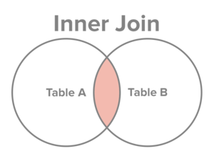

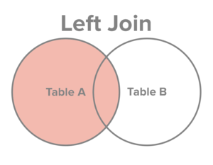

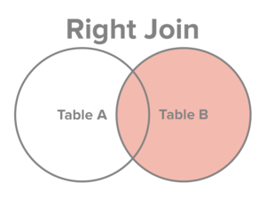

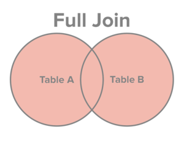

# Examples

Suppose we want to figure out the average salaries of the players with the top 10 highest homerun averages. Then we’d have to combine the two tables below

```r
dbGetQuery(con, paste("SELECT yearID, teamID, lgID, playerID, HR",
                      "FROM Batting",
                      "ORDER BY playerID",
                      "LIMIT 15"))
```

```
##    yearID teamID lgID  playerID HR
## 1    2004    SFN   NL aardsda01  0
## 2    2006    CHN   NL aardsda01  0
## 3    2007    CHA   AL aardsda01  0
## 4    2008    BOS   AL aardsda01  0
## 5    2009    SEA   AL aardsda01  0
## 6    2010    SEA   AL aardsda01  0
## 7    2012    NYA   AL aardsda01  0
## 8    2013    NYN   NL aardsda01  0
## 9    2015    ATL   NL aardsda01  0
## 10   1954    ML1   NL aaronha01 13
## 11   1955    ML1   NL aaronha01 27
## 12   1956    ML1   NL aaronha01 26
## 13   1957    ML1   NL aaronha01 44
## 14   1958    ML1   NL aaronha01 30
## 15   1959    ML1   NL aaronha01 39
```

```r
dbGetQuery(con, paste("SELECT *",
                      "FROM Salaries",
                      "ORDER BY playerID",
                      "LIMIT 15"))
```

```
##    yearID teamID lgID  playerID  salary
## 1    2004    SFN   NL aardsda01  300000
## 2    2007    CHA   AL aardsda01  387500
## 3    2008    BOS   AL aardsda01  403250
## 4    2009    SEA   AL aardsda01  419000
## 5    2010    SEA   AL aardsda01 2750000
## 6    2011    SEA   AL aardsda01 4500000
## 7    2012    NYA   AL aardsda01  500000
## 8    1986    BAL   AL  aasedo01  600000
## 9    1987    BAL   AL  aasedo01  625000
## 10   1988    BAL   AL  aasedo01  675000
## 11   1989    NYN   NL  aasedo01  400000
## 12   2006    CIN   NL  abadan01  327000
## 13   2011    HOU   NL  abadfe01  418000
## 14   2012    HOU   NL  abadfe01  485000
## 15   2014    OAK   AL  abadfe01  525900
```

We can use a `JOIN` on the pair: `yearID`, `playerID`

```r
dbGetQuery(con, paste("SELECT yearID, playerID, salary, HR",
                      "FROM Batting JOIN Salaries USING(yearID, playerID)",
                      "ORDER BY playerID",
                      "LIMIT 15"))
```

```
##    yearID  playerID  salary HR
## 1    2004 aardsda01  300000  0
## 2    2007 aardsda01  387500  0
## 3    2008 aardsda01  403250  0
## 4    2009 aardsda01  419000  0
## 5    2010 aardsda01 2750000  0
## 6    2012 aardsda01  500000  0
## 7    1986  aasedo01  600000  0
## 8    1987  aasedo01  625000  0
## 9    1988  aasedo01  675000  0
## 10   1989  aasedo01  400000  0
## 11   2006  abadan01  327000  0
## 12   2011  abadfe01  418000  0
## 13   2012  abadfe01  485000  0
## 14   2014  abadfe01  525900  0
## 15   2015  abadfe01 1087500  0
```

Note that here we’re missing 3 David Aardsma’s records (i.e., the `JOIN` discarded 3 records)

We can replicate this using `merge()` on imported data frames:

```r
batting = dbReadTable(con, "Batting")
salaries = dbReadTable(con, "Salaries")
merged = merge(x=batting, y=salaries, by.x=c("yearID","playerID"),
               by.y=c("yearID","playerID"))
merged[order(merged$playerID)[1:15],
       c("yearID", "playerID", "salary", "HR")]
```

```
##       yearID  playerID  salary HR
## 16701   2004 aardsda01  300000  0
## 19371   2007 aardsda01  387500  0
## 20270   2008 aardsda01  403250  0
## 21157   2009 aardsda01  419000  0
## 22037   2010 aardsda01 2750000  0
## 23795   2012 aardsda01  500000  0
## 578     1986  aasedo01  600000  0
## 1353    1987  aasedo01  625000  0
## 2026    1988  aasedo01  675000  0
## 2733    1989  aasedo01  400000  0
## 18458   2006  abadan01  327000  0
## 22914   2011  abadfe01  418000  0
## 23796   2012  abadfe01  485000  0
## 25594   2014  abadfe01  525900  0
## 26476   2015  abadfe01 1087500  0
```

For demonstration purposes, we can use a `LEFT JOIN` on the pair: `yearID`, `playerID`

```r
dbGetQuery(con, paste("SELECT yearID, playerID, salary, HR",
                      "FROM Batting LEFT JOIN Salaries USING(yearID, playerID)",
                      "ORDER BY playerID",
                      "LIMIT 15"))
```

```
##    yearID  playerID  salary HR
## 1    2004 aardsda01  300000  0
## 2    2006 aardsda01      NA  0
## 3    2007 aardsda01  387500  0
## 4    2008 aardsda01  403250  0
## 5    2009 aardsda01  419000  0
## 6    2010 aardsda01 2750000  0
## 7    2012 aardsda01  500000  0
## 8    2013 aardsda01      NA  0
## 9    2015 aardsda01      NA  0
## 10   1954 aaronha01      NA 13
## 11   1955 aaronha01      NA 27
## 12   1956 aaronha01      NA 26
## 13   1957 aaronha01      NA 44
## 14   1958 aaronha01      NA 30
## 15   1959 aaronha01      NA 39
```

Now we can see that we have all 9 of David Aardsma’s original records from the Batting table (i.e., the `LEFT JOIN` kept them all, and just filled in an NA value when it was missing his salary)

Currently, `RIGHT JOIN` and `FULL JOIN` are not implemented in the `RSQLite` package

Now, as to our original question (average salaries of the players with the top 10 highest homerun averages):

```r
dbGetQuery(con, paste("SELECT playerID, AVG(HR), AVG(salary)",
                      "FROM Batting JOIN Salaries USING(yearID, playerID)",
                      "GROUP BY playerID",
                      "ORDER BY Avg(HR) DESC",
                      "LIMIT 15"))
```

```
##     playerID  AVG(HR) AVG(salary)
## 1  bryankr01 39.00000      652000
## 2  pujolal01 36.93750    12752527
## 3  bondsba01 34.63636     8556606
## 4  mcgwima01 34.29412     4814021
## 5  arenano01 33.66667     2004167
## 6  howarry01 33.30000    15525500
## 7  troutmi01 33.25000     5919083
## 8  duvalad01 33.00000      510000
## 9  cartech02 32.75000     1919750
## 10 kingmda01 32.50000      908750
## 11  sosasa01 32.05263     6533474
## 12 cabremi01 31.85714    13457902
## 13 belleal01 31.75000     4996539
## 14 rodrial01 31.63636    18109830
## 15 delgaca01 31.33333     9753267
```

# Summary

| R jargon | Database jargon |
| --- | --- |
| column | field |
| row | record |
| data frame | table |
| types of the columns | table schema |
| collection of data frames | database |
| conditional indexing | `SELECT`, `FROM`, `WHERE`, `HAVING` |
| `tapply()` or other means | `GROUP BY` |
| `order()` | `ORDER BY` |
| `merge()` | `INNER JOIN` or just `JOIN` |